# Time Series Homework: Chapter 3 Lesson 1

```r
pacman::p_load(
  tidyverse,  # ggplot, mutate(), cleaning...
  tsibble,    # as_tsibble()
  fable,      # model(...), forecast(), tidy(), glance()...
  feasts,     # ACF(), PACF()
  ggtime,     # autoplot() for tsibbles
  rio,        # import()
  pander,     # pander() markdown tables
  patchwork   # + and / for ggplots
)
```

## Data

```r
manu <- rio::import("https://byuistats.github.io/timeseries/data/constructionequip_manu_orders_shipments.csv")
```

```r
# Convert character date to 'real' date type column
manu <- manu |>
  mutate(date = yearmonth(date)) |>
  as_tsibble()
```

## Questions

### Question 1 - Context and Measurement (10 points)

The first step of any time series analysis is gathering context. You cannot properly analyze data without knowing what the data is measuring. Without context, the most simple features of data can be obscure and inscrutable. This homework assignment will center around the series below.

Please research the time series. In the spaces below, give the data collection process, unit of analysis, and meaning of each observation for the series.

##### a) **Construction Equipment Manufacturing Orders and Shipments**

https://fred.stlouisfed.org/graph/?g=1f4dN

**NoteAnswer**

**Data Collection Process:**

The data in both series is sourced from the U.S. Census Bureau via the Manufacturer’s Shipments, Inventories, and Orders (M3) Survey. This survey is conducted on a *monthly* basis and involves distributing questionnaires to a representative sample of construction machinery manufacturers across the *United States*. Respondents provide information regarding their new orders, shipments, and other information, which are then aggregated, processed, and seasonally adjusted to account for regular fluctuations. The finalized data is published on FRED (Federal Reserve Economic Data), making it accessible for public use.

**Unit of Analysis:** The unit of analysis for both series is the total value in millions of US dollars in either shipments or orders during a given month. It is seasonally adjusted.

**Meaning of Each Observation:**

### Orders

Each observation in the orders time series represents the total value of new orders received by construction machinery manufacturers during a specific month. High new orders indicate increased demand and potential growth in the construction machinery sector, while declining orders may signal reduced economic activity or investment in this industry.

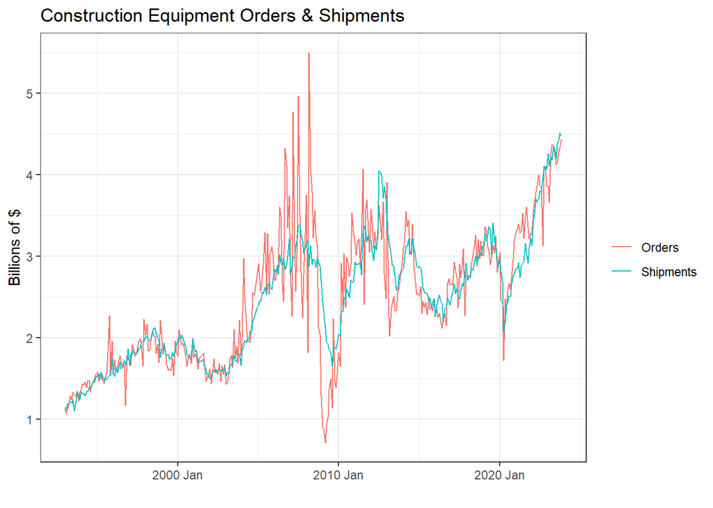

```r
# Display
ggplot(manu, aes(date)) +
  geom_line(aes(y = constructionequip_ord/1000, color = "Orders")) +
  geom_line(aes(y = constructionequip_ship/1000, color = "Shipments")) +
  theme_bw() +
  labs(
    title = "Construction Equipment Orders & Shipments",
    y = "Billions of $",
    x = "",
    color = ""
  )
```

### Question 2 - Construction Equipment Manufacturing: Graphical Analysis (15 points)

##### a) Please plot a correlogram of the random components of the New Orders and Value of Shipments for the Construction Equipment Manufacturing data. Include both plots in the same illustration as exemplified in the Figure 5 of Chapter 3 Lesson 1.

**NoteAnswer**

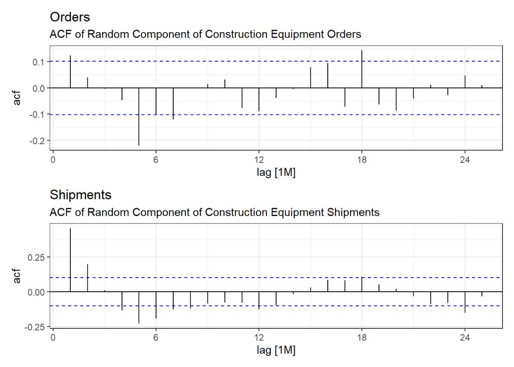

```r
# Get the random components
order <- manu |>
  model(classical_decomposition(constructionequip_ord, type = "mult")) |>
  components()

ship <- manu |>
  model(classical_decomposition(constructionequip_ship, type = "mult")) |>
  components()

# Combine in one tsibble
random <- tsibble(
  date = manu$date,         # Date from original dataset
  Orders = order$random,
  Shipments = ship$random
)

# Orders plot
acf_orders <- random |>
  ACF(y = Orders) |>
  autoplot() +
    labs(
      title = "Orders",
      subtitle = "ACF of Random Component of Construction Equipment Orders"
    ) +
    theme_bw()

# Shipments plot
acf_ships <- random |>
  ACF(y = Shipments) |>
  autoplot() +
    labs(
      title = "Shipments",
      subtitle = "ACF of Random Component of Construction Equipment Shipments") +
    theme_bw()

# Show the plots together
acf_orders / acf_ships
```

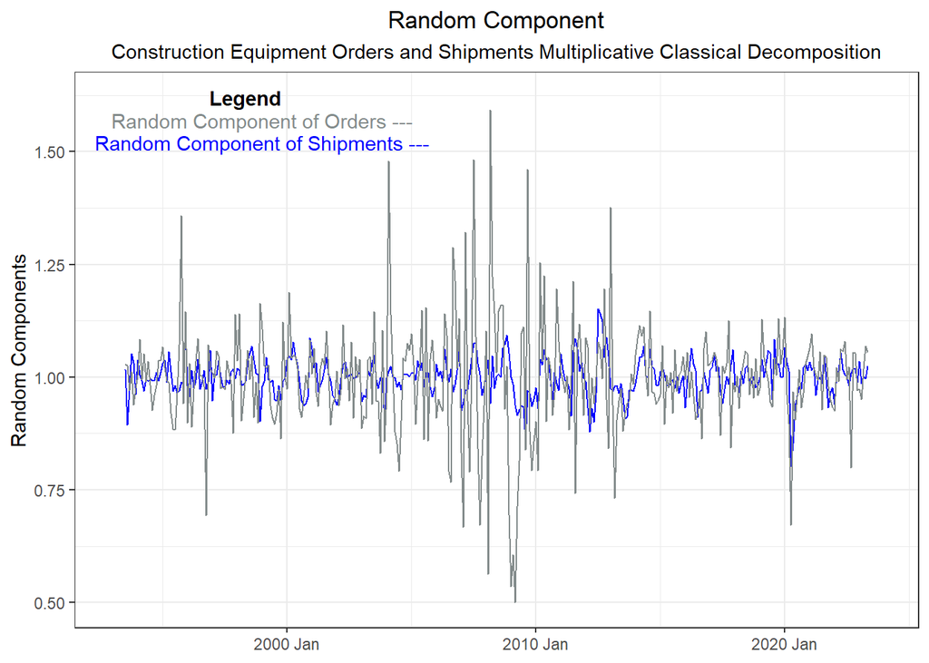

```r
# Plot random components overlayed
ggplot(random, aes(x = date)) +
  geom_line(aes(y = Shipments), color = "blue") +
  geom_line(aes(y = Orders), color = "azure4") +
  labs(
    x = NULL,
    y = "Random Components",
    title = "Random Component",
    subtitle = "Construction Equipment Orders and Shipments Multiplicative Classical Decomposition"
  ) +
  annotate("text",
           x = as.Date("1999-01-01"),
           y = 1.62,
           label = "Legend      ",
           color = "black",
           fontface = "bold") +
  annotate("text",
           x = as.Date("1999-01-01"),
           y = 1.57,
           label = "Random Component of Orders ---",
           color = "azure4") +
  annotate("text",
           x = as.Date("1999-01-01"),
           y = 1.52,
           label = "Random Component of Shipments ---",
           color = "blue") +
  theme_bw() +
  theme(
    plot.title = element_text(hjust = 0.5),
    plot.subtitle = element_text(hjust = 0.5)
  )
```

2. Interpret and analyze the correlogram of the New Orders and Value of Shipments series.

**NoteAnswer**

The lower plot, the correlogram of shipments exhibits very clear significance at lags 1 & 2. The remainder of the correlogram displays clear lingering seasonality, as such the remaining lags while statistically significant lack practical significance and application. Lags 1 & 2 however can be practically interpreted, the correlations at lags 1 & 2 inform us that the value of our shipments one month ago can tell us a significant amount about the expected values in the current month, and that the value of shipments 2 months ago can also tell us a significant amount about the expected values in the current month even after we have incorporated the additional information from lag(1) into our estimates. In both cases the lags are positively correlated so a large value in shipments last month leads us to expect a large value in shipments this month (and vice-versa).

### Question 3 - Construction Equipment Manufacturing: Cross-correlation (30 points)

##### a) Please plot a cross-correlogram of the New Orders and Value of Shipments series.

**NoteAnswer**

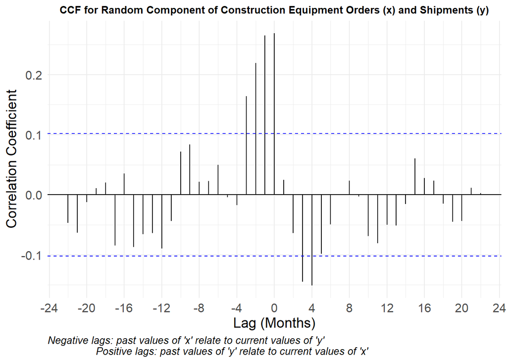

```r
random |>
  CCF(y = Shipments, x = Orders) |>
  autoplot() +
    scale_y_continuous(breaks = seq(-1, 1, 0.1)) + # Adjust y-axis for better readability
    scale_x_continuous(breaks = seq(-24, 24, 4)) + # Adjust x-axis for more details on lags
    labs(
      title = "CCF for Random Component of Construction Equipment Orders (x) and Shipments (y)",
      x = "Lag (Months)",
      y = "Correlation Coefficient",
      caption = "Negative lags: past values of 'x' relate to current values of 'y'
                Positive lags: past values of 'y' relate to current values of 'x'"
    ) +
    theme_minimal() +  # Use a clean, minimal theme
    theme(
      plot.title = element_text(hjust = 0.5, size = 10, face = "bold"), # Make title more prominent
      plot.subtitle = element_text(hjust = 0.5, size = 14), # Style subtitle consistently
      axis.title = element_text(size = 14), # Increase axis label size for readability
      axis.text = element_text(size = 12), # Increase axis text size
      plot.caption = element_text(hjust = 0, size = 10, face = "italic") # Add a descriptive caption for context
    )
```

##### b) Please interpret the cross-correlogram of the New Orders and Value of Shipments series. Include descriptions of the statistical and practical significance of the results.

**NoteAnswer**

### Rubric

| **Criteria** | **Mastery (10)** | **Incomplete (0)** |
| --- | --- | --- |
| **Question 1: Context and Measurement** | The student thoroughly researches the data collection process, unit of analysis, and meaning of each observation for both the requested time series. Clear and comprehensive explanations are provided. | The student does not adequately research or provide information on the data collection process, unit of analysis, and meaning of each observation for the specified series. |
|  | **Mastery (5)** | **Incomplete (0)** |
| **Question 2a: Correlograms** | The student plots a correlogram of the random components of the New Orders and Value of Shipments for the Construction Equipment Manufacturing data using R. The correlogram includes both plots in the … | The correlogram may be missing one or both plots, or the plots may not be correctly aligned for comparison. There may be errors in identifying or labeling the autocorrelation values, making it challen… |
|  | **Mastery (10)** | **Incomplete (0)** |
| **Question 2b: Interpretation and Analysis** | They accurately identify and discuss significant autocorrelation values at various lags, indicating the presence of temporal dependencies within each series. Additionally, the student compares and con… | The student attempts to interpret and analyze the correlogram for the New Orders and Value of Shipments series but encounters issues with accuracy, clarity, or completeness. Their discussion may lack … |
|  | **Mastery (10)** | **Incomplete (0)** |
| **Question 3a: Cross-correlogram** | The student accurately plots a cross-correlogram of the New Orders and Value of Shipments series using R. The plot includes clear labels and titles allowing for easy interpretation of the results. The… | The student attempts to plot a cross-correlogram of the New Orders and Value of Shipments series in R but encounters issues with accuracy, clarity, or completeness. The plot may lack clear labels and … |
|  | **Mastery (20)** | **Incomplete (0)** |
| **Question 3b: Interpretation and Analysis** | They accurately identify and discuss significant cross-correlation values at various lags, indicating the strength and direction of the relationship between the two series. Additionally, the student i… | The student attempts to interpret the cross-correlogram for the New Orders and Value of Shipments series but encounters issues with accuracy, clarity, or completeness. Their discussion may lack depth … |
| **Total Points** | **55** |  |